# 第11回 主成分分析による次元の削減

# 5. 見分ける力は残るか？

## 段5：見分ける

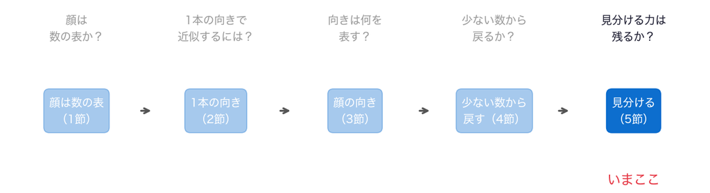

- 問い：少ない数で持った顔で、誰の顔かを見分ける力は残るか

## 前の段から

- 50個の得点から、顔はほぼ戻る。累積寄与率は88%
- 残りの12%を捨てて、見分ける力は落ちないか
- 見分ける力を、物差しにして確かめる

## いちばん近い顔で見分ける

5節 ① 最近傍●○○○

- テストの顔に、いちばん近い訓練の顔を探す
- その顔の人の番号を、答えにする（1-最近傍法）
- 近さは、画素ごとの差を2乗して足したもの（距離の二乗）

## お手本：いちばん近い顔

5節 ① 最近傍●●○○

```python
d = ((X_tr - X_te[0]) ** 2).sum(axis=1)
near = np.argmin(d)
print(near, p_tr[near], p_te[0])
```

```
169 36 36
```

## 1行ずつ：いちばん近い顔

5節 ① 最近傍●●●○

```python
d = ((X_tr - X_te[0]) ** 2).sum(axis=1)
near = np.argmin(d)
print(near, p_tr[near], p_te[0])
```

- 1行目：訓練の300枚それぞれから、テストの0枚目を引き、2乗して横に足す。300個の距離
- 2行目：いちばん近い訓練の顔の番号
- 3行目：その顔の人の番号と、本当の人の番号

## 中身を見る：近い顔

5節 ① 最近傍●●●●

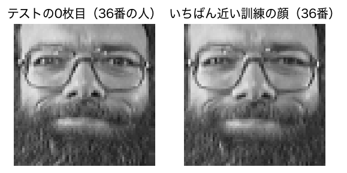

- 同じ36番の人。表情と向きが少し違う写真が選ばれた

## お手本：道具で見分ける

5節 ② 道具●○○

```python
from sklearn.neighbors import KNeighborsClassifier
knn = KNeighborsClassifier(n_neighbors=1)
knn.fit(X_tr, p_tr)
print(knn.predict(X_te[:1]))
```

```
[36]
```

## 1行ずつ：道具で見分ける

5節 ② 道具●●○

```python
from sklearn.neighbors import KNeighborsClassifier
knn = KNeighborsClassifier(n_neighbors=1)
knn.fit(X_tr, p_tr)
print(knn.predict(X_te[:1]))
```

- 1・2行目：最近傍法の道具を、いちばん近い1枚で決める設定で用意する
- 3行目：訓練の顔と人の番号を覚える（`fit`）
- 4行目：テストの0枚目を見分ける。上の計算と同じ36番

## 最近傍の道具がしていること

5節 ② 道具●●●

- `fit`では、訓練の顔と番号を覚えるだけ
- `predict`では、上のお手本と同じく、いちばん近い訓練の顔を探す
- その顔の番号を返す

## お手本：画素そのままで測る

5節 ③ 交差検証●○

```python
from sklearn.model_selection import StratifiedKFold, cross_val_score
skf = StratifiedKFold(5, shuffle=True, random_state=0)
sc = cross_val_score(knn, X_tr, p_tr, cv=skf)
print(sc.mean().round(3))
```

```
0.907
```

## 1行ずつ：画素そのままで測る

5節 ③ 交差検証●●

```python
from sklearn.model_selection import StratifiedKFold, cross_val_score
skf = StratifiedKFold(5, shuffle=True, random_state=0)
sc = cross_val_score(knn, X_tr, p_tr, cv=skf)
print(sc.mean().round(3))
```

- 2行目：訓練の300枚を、人の割合をそろえて5組に分ける（第4回の交差検証）
- 3行目：組ごとに、4組で覚えて残り1組を見分け、正解率を出す
- 4行目：5つの正解率の平均。4,096個の数そのままで0.907

## 縮めてから見分ける

5節 ④ パイプライン●○○○

- 4,096個を`PCA`で50個にしてから、いちばん近い顔を探す
- `PCA`の向きも、覚える組だけで求めないと、測る組の情報がもれる
- そこで、`PCA`と見分ける道具を、パイプラインでつなぐ（第7回）

## お手本：50本で測る

5節 ④ パイプライン●●○○

```python
from sklearn.pipeline import make_pipeline
pipe = make_pipeline(PCA(50, random_state=0),
                     KNeighborsClassifier(n_neighbors=1))
sc = cross_val_score(pipe, X_tr, p_tr, cv=skf)
print(sc.mean().round(3))
```

```
0.9
```

## 1行ずつ：50本で測る

5節 ④ パイプライン●●●○

```python
from sklearn.pipeline import make_pipeline
pipe = make_pipeline(PCA(50, random_state=0),
                     KNeighborsClassifier(n_neighbors=1))
sc = cross_val_score(pipe, X_tr, p_tr, cv=skf)
print(sc.mean().round(3))
```

- 2・3行目：50本の`PCA` → 最近傍法の順につなぐ
- 4行目：組ごとに、覚える組で向きを求め、測る組を縮めてから見分ける
- 5行目：0.900。画素そのまま（0.907）とほぼ同じ

## 本数ごとの正解率

5節 ④ パイプライン●●●●

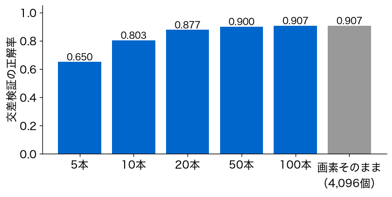

- 50本で、4,096個とほぼ同じ。5本や10本では、はっきり落ちる

## お手本：テストで1回だけ

5節 ⑤ テスト●○○

```python
knn.fit(X_tr, p_tr)
pipe.fit(X_tr, p_tr)
print(knn.score(X_te, p_te), pipe.score(X_te, p_te))
```

```
0.93 0.93
```

- 50本に決めてから、テストの100枚で1回だけ測る。どちらも0.93

## 1行ずつ：テストで1回だけ

5節 ⑤ テスト●●○

```python
knn.fit(X_tr, p_tr)
pipe.fit(X_tr, p_tr)
print(knn.score(X_te, p_te), pipe.score(X_te, p_te))
```

- 1・2行目：訓練の300枚すべてで覚え直す
- 3行目：テストの100枚の正解率（`score`）。画素そのままと、50本

## 重要：縮めても、見分ける力は残る

5節 ⑤ テスト●●●

顔どうしは似ているので、ずれの大部分は少ない向きで持てる。4,096個を50個にしても、見分ける力はほとんど落ちない。

## TODO⑤：本数を10にする

5節 ⑥ 本数を減らす●○

```python
# TODO: 50 を 10 に替えて実行する
pipe_x = make_pipeline(PCA(50, random_state=0),
                       KNeighborsClassifier(n_neighbors=1))
print(cross_val_score(pipe_x, X_tr, p_tr, cv=skf).mean().round(3))
```

- 予想：10個の数にすると、交差検証の正解率はどこまで下がるか

## ここまでで分かったこと

5節 ⑥ 本数を減らす●●

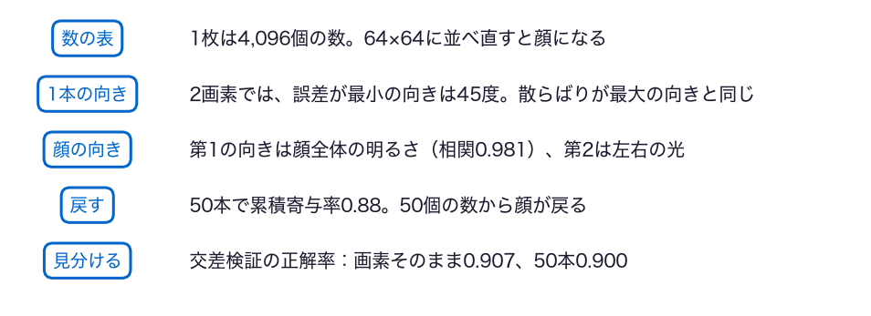

- 5つの段がそろい、今日の問いに答えられる

## ノートへ：5節

5節 ⑦ ノートへ●

- 5節のセルを上から実行し、スライドと同じ数が出るか確かめる
- TODO⑤：予想を書く → `50`を`10`に替えて実行 → 予想と比べる

動画の人は、ここで一時停止。

## 答え合わせ：TODO⑤

5節 ⑧ 答え合わせ●

```
10本 0.803  20本 0.877
```

- 10本では0.803。累積寄与率は65.5%で、見分ける力もはっきり落ちる
- 20本なら0.877、50本で0.900

## 答え：50個で持てる

5節 ⑨ 答え●

- 顔の画像1枚の4,096個は、50個の得点で持てる（累積寄与率88%）
- 50個でも、見分ける力はほとんど落ちない（交差検証0.900、テスト0.93）
- いちばん大きい向きは、人の違いではなく、明るさと光の向きだった

## まだ言えないこと

5節 10 まだ言えないこと●

- 何本が正しいか。使い方（見分けるか、きれいに戻すか）で変わる
- 向きの意味の読み方。今日は両端の顔を見ただけ
- 光の当たり方や写り方が大きく違う写真でも、同じように言えるか

# まとめ

## 今日の道筋を振り返る

⑨ 振り返る●○○○

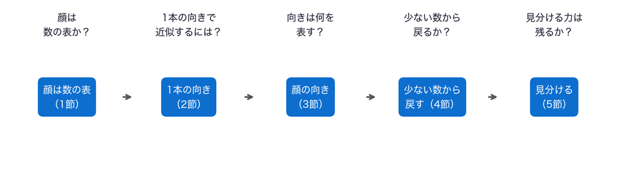

- 顔を数の表として見て、2画素で向きを探し、顔の向きを描き、少ない数から戻し、見分ける力を測った

## 今日持ち帰る1文

⑨ 振り返る●●○○

主成分分析は、平均からのずれを、誤差が最小（散らばりが最大）の向きで近似する。顔の4,096個の数は、50個の得点にしても、見分ける力をほとんど失わない。

## 今日の重要概念

⑨ 振り返る●●●○

統計：主成分分析は、平均からのずれを、誤差が最小の向きで近似する。誤差が最小の向きは、散らばりが最大の向きでもある。

Python：reshapeは、配列の形を替える。並びの順はそのままで、前から順に新しい形に詰める。

## 今日の要点

⑨ 振り返る●●●●

- 縮める（ずれ`@`向きの転置）も、戻す（得点`@`向き＋平均）も、行列の積
- 累積寄与率で、何本で何割を持てるかを読む
- いちばん大きい向きが、知りたい違いを表すとは限らない

## レポートなら、こう書く①

10 レポートなら●○

- 予想：顔どうしは似ているので、4,096個も要らないだろう
- 解析：訓練の300枚で主成分分析をかけ、上の向きの得点で顔を持った
- 驚き：第1の向きは顔全体の明るさ（相関0.981）、第2は左右の光だった

## レポートなら、こう書く②

10 レポートなら●●

- 本数：累積寄与率は50本で88%。50本で顔がほぼ戻る
- 確かめ：最近傍法の交差検証で、画素そのまま0.907、50本0.900。テストではどちらも0.93
- 限界：本数は使い方で決めた。写り方の違う写真では確かめていない

## 課題の出し方

11 このあと●○○

- 今日の重要概念は、統計の「主成分分析」と、Pythonの「reshape」
- 2つを1枚ずつ絵にし、2枚をLACSに提出（＝出席。期限なし）
- 手描きの写真でも、描画アプリでもよい。上手でなくてよい

## 次回の問い

11 このあと●●○

- 今日は、向きの意味を、両端の顔を見て読んだ
- 列に名前のあるデータでは、向きの意味をどう読めばよいか

## このあと：課題へ

11 このあと●●●

- ノートの最後の「課題（提出）」を開く
- 絵を描き終えたら、このあとの「解答」で、絵の例と見比べる

# ここから先は解答

## 課題のあとで見る

- ここから先は、課題の絵を描き終えてから見る
- 絵の例を2つ見せる。上手さではなく、考えが伝わるかを見比べる

## 絵の例：主成分分析

- 細長いパンを、真上・真横・正面から写真に撮る
- 形がいちばんよく分かるのは、影がいちばん長くなる向き（散らばりが最大）
- その向きで撮れば、写真1枚で失うもの（誤差）がいちばん少ない

## 絵の例：reshape

- 1列に並んだ12個の卵を、3×4のパックに詰める
- 前から順に、1段目に4個、2段目に4個、3段目に4個
- パックから出して並べ直せば、もとの1列に戻る

# 発展（任意）

## 向きに沿って、顔を動かす

- 平均の顔に、向きを少しずつ足したり引いたりすると、その向きの意味が見える
- 動かす量は、得点の標準偏差の何倍か
- 第1と第2の向きで試す

## お手本：第1の向きに動かす

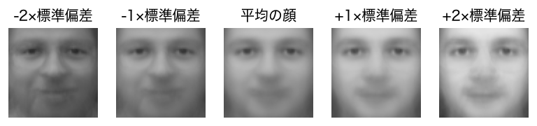

```python
sd = t_all[:, 0].std()
for j in range(5):
    face = mean_face + (j - 2) * sd * pca.components_[0]
    plt.subplot(1, 5, j + 1)
    plt.imshow(face.reshape(64, 64), cmap='gray', vmin=0, vmax=1)
    plt.axis('off')
plt.show()
```

## 1行ずつ：第1の向きに動かす

```python
sd = t_all[:, 0].std()
for j in range(5):
    face = mean_face + (j - 2) * sd * pca.components_[0]
    plt.subplot(1, 5, j + 1)
    plt.imshow(face.reshape(64, 64), cmap='gray', vmin=0, vmax=1)
    plt.axis('off')
plt.show()
```

- 1行目：第1の得点の標準偏差
- 2・3行目：−2倍から＋2倍まで5通り、平均の顔に向きを足す
- 5行目：`vmin`・`vmax`で、明るさの0と1を黒と白にそろえる

## 第2の向きに動かすと

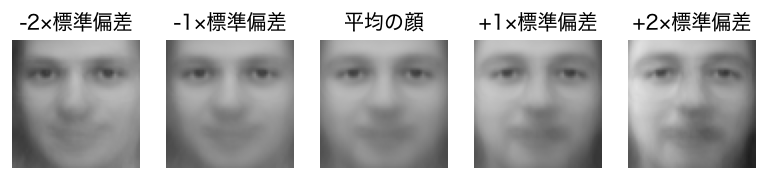

- 光が左右に動く。試すなら、`components_[0]`の`0`を`2`や`3`に替える（得点の`[:, 0]`も同じ番号に）

## おわり

- お疲れさまでした